# IE360 Fall

Homework 5

Fatma Nur Dumlupınar

18 02 2021

# 1 Introduction

In this assignment, variables that can affect sales have been analyzed with the correlation matrix and scatter plots by using sales data. Accordingly, the regression model was established using the stepwise regression steps. Also, the results were compared using the step() function in R. Required packages and data can be seen below.

```r
library(data.table)
library(corrplot)
library(ggplot2)
library(hrbrthemes)
library(psych)
library(forecast)
library(MASS)

data<-fread("sales.txt")
str(data)
```

```
## Classes 'data.table' and 'data.frame':   30 obs. of  6 variables:
##  $ SALES: int  44 47 60 71 61 60 58 56 66 61 ...
##  $ APT  : int  10 19 27 31 64 81 42 67 48 64 ...
##  $ AGE  : num  22.1 22.4 23.1 24 22.6 21.6 23.8 22 22.3 22.5 ...
##  $ ANX  : num  4.9 3 1.5 0.6 1.8 3.3 3.2 2.1 6 1.8 ...
##  $ EXP  : int  0 1 0 3 2 1 0 0 1 1 ...
##  $ GPA  : num  2.4 2.6 2.8 2.7 2 2.5 2.5 2.3 2.8 3.3 ...
##  - attr(*, ".internal.selfref")=<externalptr>
```

# 2 Analysis

## 2.1 PART A

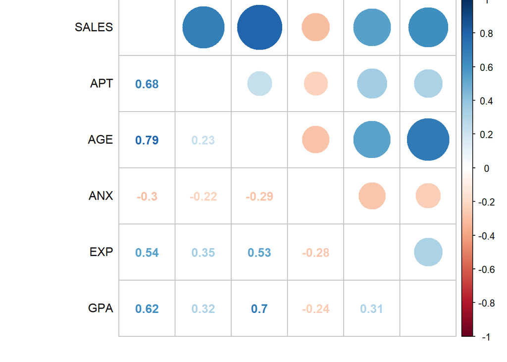

```r
cor_numVar <- cor(data, use="pairwise.complete.obs")

corrplot.mixed(cor_numVar, tl.col="black", tl.pos = "lt")
```

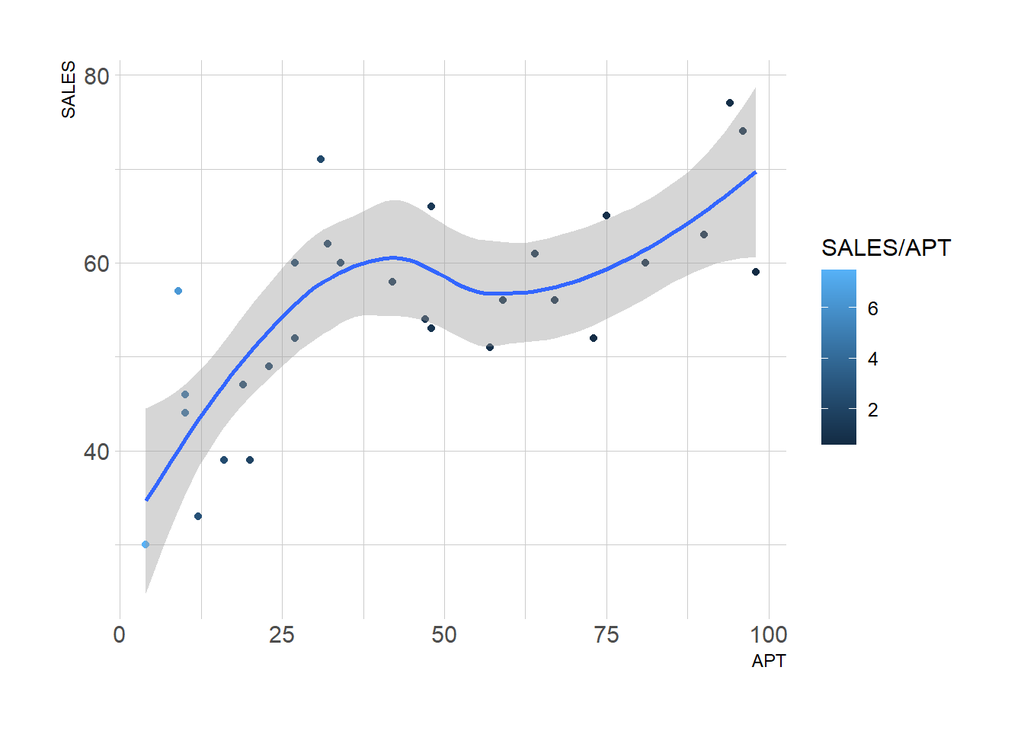

```r
ggplot(data,aes(x=APT,y=SALES))+
  geom_point(aes(color=SALES/APT))+
  geom_smooth()+
  theme_ipsum()
```

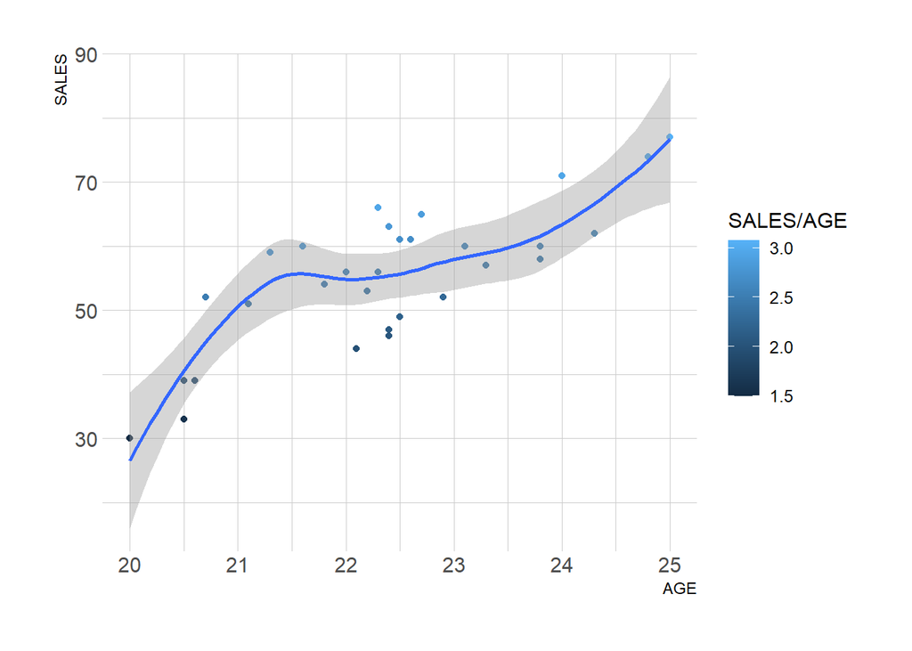

```r
ggplot(data,aes(x=AGE,y=SALES))+
  geom_point(aes(color=SALES/AGE))+
  geom_smooth()+
  theme_ipsum()
```

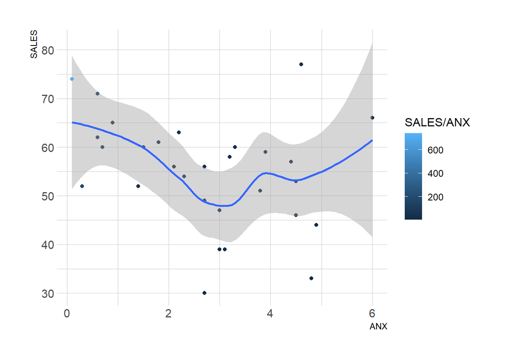

```r
ggplot(data,aes(x=ANX,y=SALES))+
  geom_point(aes(color=SALES/ANX))+
  geom_smooth()+
  theme_ipsum()
```

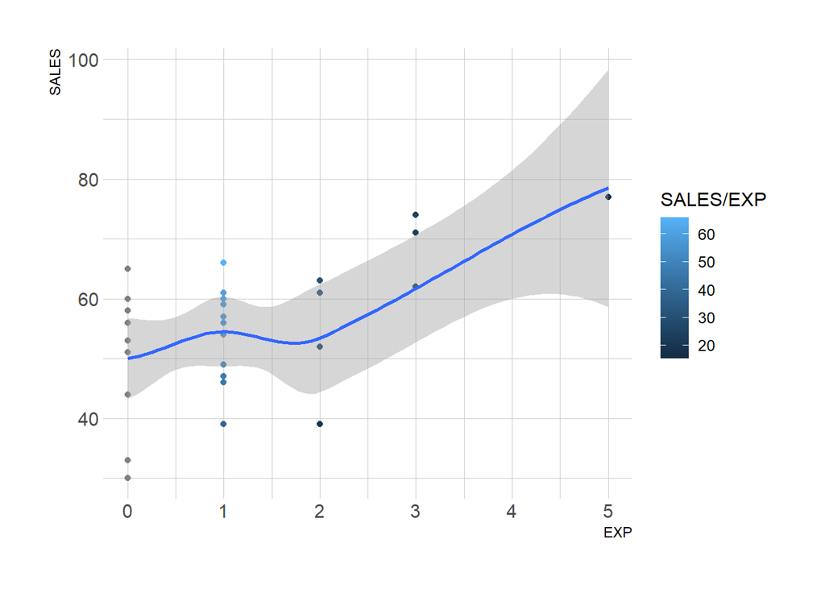

```r
ggplot(data,aes(x=EXP,y=SALES))+
  geom_point(aes(color=SALES/EXP))+
  geom_smooth()+
  theme_ipsum()
```

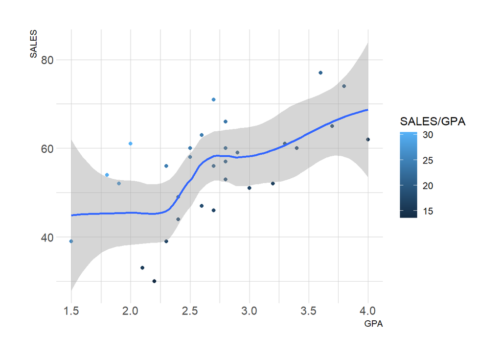

```r
ggplot(data,aes(x=GPA,y=SALES))+
  geom_point(aes(color=SALES/GPA))+
  geom_smooth()+
  theme_ipsum()
```

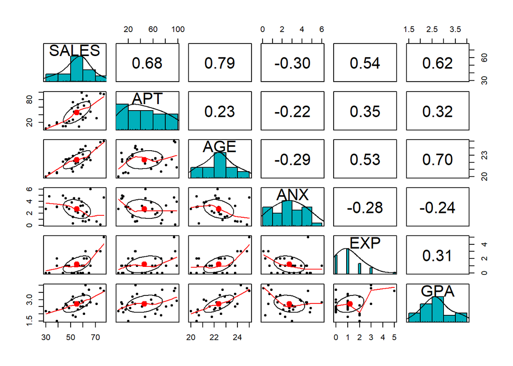

```r
pairs.panels(data,
             method = "pearson", # correlation method
             hist.col = "#00AFBB",
             density = TRUE,  # show density plots
             ellipses = TRUE # show correlation ellipses
)
```

When choosing the first variables for the model, we must basically consider two things. The first is that the correlation between the dependent variable and the independent variable is high. Second, not choosing two independent variables with high correlation at the same time. When we think in this way, we see that the correlation of variables other than ANX with sales is high. We should not use ANX variable with low correlation in the model. Moreover, since the correlation values between AGE-GPA and AGE-EXP pairs are high, it would be reasonable not to use these pairs in the same model. We see that the correlation of AGE variable with sales is higher compared to the other two variables. For this reason, using the AGE variable may give a better result. In the last case, we can say that AGE and remaining APT variables are required for the model. The results we obtained from scatter plots also confirm the correlation matrix. Likewise, we can see that there is no linear relationship between ANX variable and sales, but a linear relationship in AGE-EXP and AGE-GPA pairs.

## 2.2 PART B

### 2.2.1 Stepwise Regression

**Step 1**

The variable having the highest absolute correlation value, which is AGE, is chosen in the initial model.

```r
fit1<-lm(SALES~AGE,data=data)
```

**Step 2**

Remaining variables are added to the model separately, and the significance of the new variable is tested with an F-test.

```r
fit2<-lm(SALES~AGE+APT,data=data)
anova(fit1,fit2)
```

```
## Analysis of Variance Table
##
## Model 1: SALES ~ AGE
## Model 2: SALES ~ AGE + APT
##   Res.Df     RSS Df Sum of Sq      F Pr(>F)
## 1     28 1334.50
## 2     27  387.47  1    947.03 65.992  1e-08 ***
## ---
## Signif. codes:  0 '***' 0.001 '**' 0.01 '*' 0.05 '.' 0.1 ' ' 1
```

```r
fit3<-lm(SALES~AGE+GPA,data=data)
anova(fit1,fit3)
```

```
## Analysis of Variance Table
##
## Model 1: SALES ~ AGE
## Model 2: SALES ~ AGE + GPA
##   Res.Df    RSS Df Sum of Sq      F Pr(>F)
## 1     28 1334.5
## 2     27 1307.9  1    26.638 0.5499 0.4648
```

```r
fit4<-lm(SALES~AGE+EXP,data=data)
anova(fit1,fit4)
```

```
## Analysis of Variance Table
##
## Model 1: SALES ~ AGE
## Model 2: SALES ~ AGE + EXP
##   Res.Df    RSS Df Sum of Sq      F Pr(>F)
## 1     28 1334.5
## 2     27 1259.4  1    75.128 1.6107 0.2152
```

```r
fit5<-lm(SALES~AGE+ANX,data=data)
anova(fit1,fit5)
```

```
## Analysis of Variance Table
##
## Model 1: SALES ~ AGE
## Model 2: SALES ~ AGE + ANX
##   Res.Df    RSS Df Sum of Sq      F Pr(>F)
## 1     28 1334.5
## 2     27 1312.5  1     21.98 0.4522  0.507
```

```r
#APT is selected, current model with AGE, APT
```

The variable that corresponds to largest F-statistic, which is APT, is selected and the model is updated by adding APT.

**Step 3**

The model is built by removing each variable in the current model separately (except the last one added to the model). The significance of the removed variable is tested with an F-test.

```r
fit1<-lm(SALES~AGE+APT,data=data)

fit2<-lm(SALES~APT,data=data)
anova(fit1,fit2)
```

```
## Analysis of Variance Table
##
## Model 1: SALES ~ AGE + APT
## Model 2: SALES ~ APT
##   Res.Df     RSS Df Sum of Sq      F    Pr(>F)
## 1     27  387.47
## 2     28 1902.00 -1   -1514.5 105.54 7.939e-11 ***
## ---
## Signif. codes:  0 '***' 0.001 '**' 0.01 '*' 0.05 '.' 0.1 ' ' 1
```

```r
# dont change the current model, current model with AGE, APT
```

The F-statistic is higher than the critical F value, so the model is not changed.

**Step 4**

Steps 2 and 3 are repeated until all possible additions are nonsignificant and all possible deletions are significant.

*Back to Step 2*

Remaining variables are added to the model separately, and the significance of the new variable is tested with an F-test.

```r
fit1<-lm(SALES~AGE+APT,data=data)

fit2<-lm(SALES~AGE+APT+GPA,data=data)
anova(fit1,fit2)
```

```
## Analysis of Variance Table
##
## Model 1: SALES ~ AGE + APT
## Model 2: SALES ~ AGE + APT + GPA
##   Res.Df    RSS Df Sum of Sq      F Pr(>F)
## 1     27 387.47
## 2     26 384.56  1    2.9087 0.1967 0.6611
```

```r
fit3<-lm(SALES~AGE+APT+EXP,data=data)
anova(fit1,fit3)
```

```
## Analysis of Variance Table
##
## Model 1: SALES ~ AGE + APT
## Model 2: SALES ~ AGE + APT + EXP
##   Res.Df    RSS Df Sum of Sq      F Pr(>F)
## 1     27 387.47
## 2     26 387.42  1  0.047057 0.0032 0.9556
```

```r
fit4<-lm(SALES~AGE+APT+ANX,data=data)
anova(fit1,fit4)
```

```
## Analysis of Variance Table
##
## Model 1: SALES ~ AGE + APT
## Model 2: SALES ~ AGE + APT + ANX
##   Res.Df    RSS Df Sum of Sq     F Pr(>F)
## 1     27 387.47
## 2     26 387.27  1   0.19312 0.013 0.9102
```

```r
# smallest pvalue with variable GPA which will be added to the model
```

The variable that corresponds to largest F-statistic, which is GPA, is selected and the model is updated by adding GPA.

*Step 3*

The model is built by removing each variable in the current model separately (except the last one added to the model). The significance of the removed variable is tested with an F-test.

```r
fit1<-lm(SALES~AGE+APT+GPA,data=data)

fit2<-lm(SALES~APT+GPA,data=data)
anova(fit1,fit2)
```

```
## Analysis of Variance Table
##
## Model 1: SALES ~ AGE + APT + GPA
## Model 2: SALES ~ APT + GPA
##   Res.Df     RSS Df Sum of Sq      F   Pr(>F)
## 1     26  384.56
## 2     27 1261.88 -1   -877.32 59.316 3.58e-08 ***
## ---
## Signif. codes:  0 '***' 0.001 '**' 0.01 '*' 0.05 '.' 0.1 ' ' 1
```

```r
fit3<-lm(SALES~AGE+GPA,data=data)
anova(fit1,fit3)
```

```
## Analysis of Variance Table
##
## Model 1: SALES ~ AGE + APT + GPA
## Model 2: SALES ~ AGE + GPA
##   Res.Df     RSS Df Sum of Sq      F    Pr(>F)
## 1     26  384.56
## 2     27 1307.86 -1    -923.3 62.425 2.233e-08 ***
## ---
## Signif. codes:  0 '***' 0.001 '**' 0.01 '*' 0.05 '.' 0.1 ' ' 1
```

```r
# F-statistics are high, dont change the model
# variables in the current model: AGE,APT,GPA
```

The F-statistics are higher than the critical F value, so the model is not changed.

*Back to Step 2*

Remaining variables are added to the model separately, and the significance of the new variable is tested with an F-test.

```r
fit1<-lm(SALES~AGE+APT+GPA,data=data)

fit2<-lm(SALES~AGE+APT+GPA+EXP,data=data)
anova(fit1,fit2)
```

```
## Analysis of Variance Table
##
## Model 1: SALES ~ AGE + APT + GPA
## Model 2: SALES ~ AGE + APT + GPA + EXP
##   Res.Df    RSS Df Sum of Sq     F Pr(>F)
## 1     26 384.56
## 2     25 384.55  1 0.0057012 4e-04 0.9848
```

```r
fit3<-lm(SALES~AGE+APT+GPA+ANX,data=data)
anova(fit1,fit3)
```

```
## Analysis of Variance Table
##
## Model 1: SALES ~ AGE + APT + GPA
## Model 2: SALES ~ AGE + APT + GPA + ANX
##   Res.Df    RSS Df Sum of Sq      F Pr(>F)
## 1     26 384.56
## 2     25 384.40  1   0.16266 0.0106 0.9189
```

```r
#smallest pvalue with the variable ANX which will be added to the model
```

The variable that corresponds to largest F-statistic, which is ANX, is selected and the model is updated by adding ANX.

*Step 3*

The model is built by removing each variable in the current model separately (except the last one added to the model). The significance of the removed variable is tested with an F-test.

```r
fit1<-lm(SALES~AGE+APT+GPA+ANX,data=data)

fit2<-lm(SALES~APT+GPA+ANX,data=data)
anova(fit1,fit2)
```

```
## Analysis of Variance Table
##
## Model 1: SALES ~ AGE + APT + GPA + ANX
## Model 2: SALES ~ APT + GPA + ANX
##   Res.Df    RSS Df Sum of Sq      F    Pr(>F)
## 1     25  384.4
## 2     26 1239.7 -1   -855.26 55.624 8.236e-08 ***
## ---
## Signif. codes:  0 '***' 0.001 '**' 0.01 '*' 0.05 '.' 0.1 ' ' 1
```

```r
fit3<-lm(SALES~AGE+GPA+ANX,data=data)
anova(fit1,fit3)
```

```
## Analysis of Variance Table
##
## Model 1: SALES ~ AGE + APT + GPA + ANX
## Model 2: SALES ~ AGE + GPA + ANX
##   Res.Df    RSS Df Sum of Sq      F    Pr(>F)
## 1     25  384.4
## 2     26 1288.5 -1   -904.11 58.801 5.042e-08 ***
## ---
## Signif. codes:  0 '***' 0.001 '**' 0.01 '*' 0.05 '.' 0.1 ' ' 1
```

```r
fit4<-lm(SALES~AGE+APT+ANX,data=data)
anova(fit1,fit4)
```

```
## Analysis of Variance Table
##
## Model 1: SALES ~ AGE + APT + GPA + ANX
## Model 2: SALES ~ AGE + APT + ANX
##   Res.Df    RSS Df Sum of Sq      F Pr(>F)
## 1     25 384.40
## 2     26 387.27 -1   -2.8783 0.1872  0.669
```

```r
# Fstatistic is smaller than the critical value when removing GPA from the model.
# current model with the variable AGE,APT,ANX
```

Since F-statistic is small then critical F value when testing the significance of the removed GPA, the current model is updated by removing GPA.

*Back to Step 2*

```r
# no other variable to add
```

*Step 3*

The model is built by removing each variable in the current model separately (except the last one added to the model). The significance of the removed variable is tested with an F-test.

```r
# backward

fit1<-lm(SALES~AGE+APT+ANX ,data=data)

fit2<-lm(SALES~AGE+APT ,data=data)
anova(fit1,fit2)
```

```
## Analysis of Variance Table
##
## Model 1: SALES ~ AGE + APT + ANX
## Model 2: SALES ~ AGE + APT
##   Res.Df    RSS Df Sum of Sq     F Pr(>F)
## 1     26 387.27
## 2     27 387.47 -1  -0.19312 0.013 0.9102
```

```r
fit3<-lm(SALES~AGE+ANX ,data=data)
anova(fit1,fit3)
```

```
## Analysis of Variance Table
##
## Model 1: SALES ~ AGE + APT + ANX
## Model 2: SALES ~ AGE + ANX
##   Res.Df     RSS Df Sum of Sq      F    Pr(>F)
## 1     26  387.27
## 2     27 1312.52 -1   -925.25 62.117 2.338e-08 ***
## ---
## Signif. codes:  0 '***' 0.001 '**' 0.01 '*' 0.05 '.' 0.1 ' ' 1
```

```r
fit4<-lm(SALES~APT+ANX ,data=data)
anova(fit1,fit4)
```

```
## Analysis of Variance Table
##
## Model 1: SALES ~ AGE + APT + ANX
## Model 2: SALES ~ APT + ANX
##   Res.Df     RSS Df Sum of Sq     F    Pr(>F)
## 1     26  387.27
## 2     27 1814.67 -1   -1427.4 95.83 3.297e-10 ***
## ---
## Signif. codes:  0 '***' 0.001 '**' 0.01 '*' 0.05 '.' 0.1 ' ' 1
```

```r
# F-statistic is smaller than the critical value when removing ANX, ANX is removed
#variables in the final model: AGE, APT
```

Since F-statistic is small then critical F value when testing the significance of the removed ANX, the current model is updated by removing ANX. So the variables in the current model: AGE, APT. This scenario is tested at the beginning. So, there is no need to iterate again with these variable.

### 2.2.2 Final Model

The final model received from stepwise regression is as follows:

```r
fit1<-lm(SALES~AGE+APT ,data=data)
summary(fit1)
```

```
##
## Call:
## lm(formula = SALES ~ AGE + APT, data = data)
##
## Residuals:
##    Min     1Q Median     3Q    Max
## -5.271 -2.275 -1.065  1.415 10.893
##
## Coefficients:
##             Estimate Std. Error t value Pr(>|t|)
## (Intercept) -83.8357    12.4356  -6.742 3.08e-07 ***
## AGE           5.7969     0.5643  10.273 7.94e-11 ***
## APT           0.2015     0.0248   8.124 1.00e-08 ***
## ---
## Signif. codes:  0 '***' 0.001 '**' 0.01 '*' 0.05 '.' 0.1 ' ' 1
##
## Residual standard error: 3.788 on 27 degrees of freedom
## Multiple R-squared:  0.8916, Adjusted R-squared:  0.8836
## F-statistic:   111 on 2 and 27 DF,  p-value: 9.404e-14
```

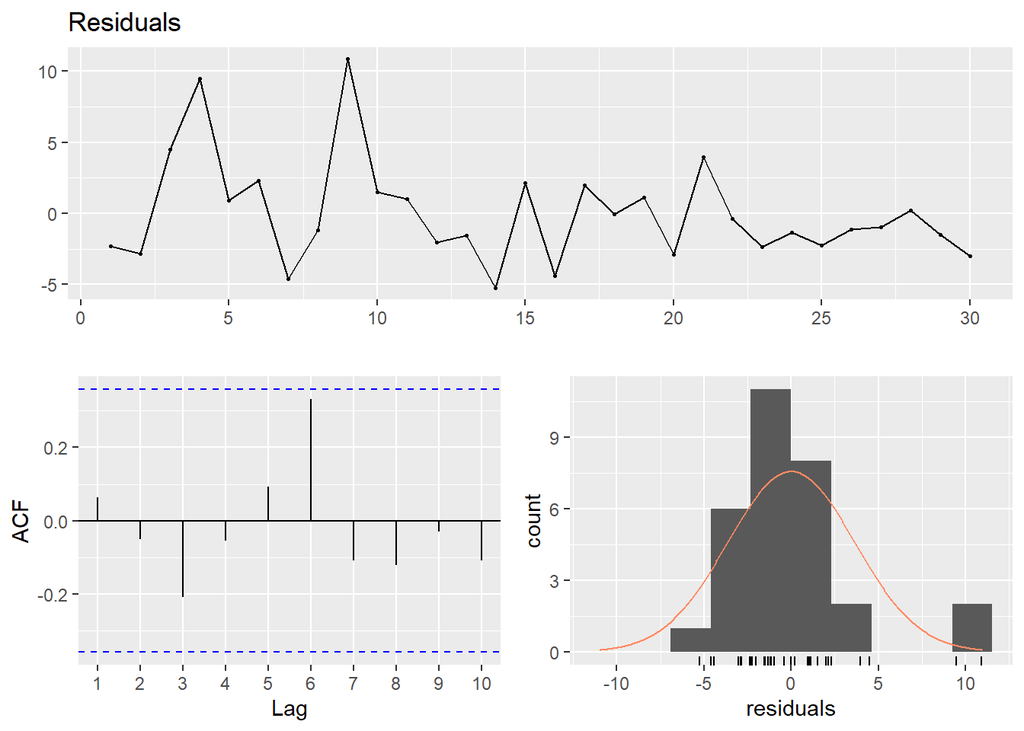

```
##
##  Breusch-Godfrey test for serial correlation of order up to 6
##
## data:  Residuals
## LM test = 4.3794, df = 6, p-value = 0.6255
```

```r
checkresiduals(fit1)
```

## 2.3 PART C

The resulted model coming from step() function is the same as the model received previously.

```r
summary(lm1 <- lm(SALES ~ ., data = data))
```

```
##
## Call:
## lm(formula = SALES ~ ., data = data)
##
## Residuals:
##     Min      1Q  Median      3Q     Max
## -5.1311 -2.3233 -0.7582  1.4826 10.8094
##
## Coefficients:
##               Estimate Std. Error t value Pr(>|t|)
## (Intercept) -87.753041  17.967690  -4.884 5.58e-05 ***
## APT           0.204530   0.028419   7.197 1.95e-07 ***
## AGE           6.051236   0.931879   6.494 1.03e-06 ***
## ANX           0.050373   0.507613   0.099    0.922
## EXP          -0.005443   0.787334  -0.007    0.995
## GPA          -0.754692   1.802770  -0.419    0.679
## ---
## Signif. codes:  0 '***' 0.001 '**' 0.01 '*' 0.05 '.' 0.1 ' ' 1
##
## Residual standard error: 4.002 on 24 degrees of freedom
## Multiple R-squared:  0.8925, Adjusted R-squared:   0.87
## F-statistic: 39.83 on 5 and 24 DF,  p-value: 7.424e-11
```

```r
slm1 <- step(lm1,direction = "both")
```

```
## Start:  AIC=88.51
## SALES ~ APT + AGE + ANX + EXP + GPA
##
##        Df Sum of Sq     RSS     AIC
## - EXP   1      0.00  384.40  86.514
## - ANX   1      0.16  384.55  86.527
## - GPA   1      2.81  387.20  86.732
## <none>               384.40  88.514
## - AGE   1    675.36 1059.76 116.938
## - APT   1    829.61 1214.00 121.014
##
## Step:  AIC=86.51
## SALES ~ APT + AGE + ANX + GPA
##
##        Df Sum of Sq     RSS     AIC
## - ANX   1      0.16  384.56  84.527
## - GPA   1      2.88  387.27  84.738
## <none>               384.40  86.514
## + EXP   1      0.00  384.40  88.514
## - AGE   1    855.26 1239.66 119.642
## - APT   1    904.11 1288.51 120.801
##
## Step:  AIC=84.53
## SALES ~ APT + AGE + GPA
##
##        Df Sum of Sq     RSS     AIC
## - GPA   1      2.91  387.47  82.753
## <none>               384.56  84.527
## + ANX   1      0.16  384.40  86.514
## + EXP   1      0.01  384.55  86.527
## - AGE   1    877.32 1261.88 118.175
## - APT   1    923.30 1307.86 119.249
##
## Step:  AIC=82.75
## SALES ~ APT + AGE
##
##        Df Sum of Sq     RSS     AIC
## <none>               387.47  82.753
## + GPA   1      2.91  384.56  84.527
## + ANX   1      0.19  387.27  84.738
## + EXP   1      0.05  387.42  84.749
## - APT   1    947.03 1334.50 117.853
## - AGE   1   1514.54 1902.00 128.484
```

```r
summary(slm1)
```

```
##
## Call:
## lm(formula = SALES ~ APT + AGE, data = data)
##
## Residuals:
##    Min     1Q Median     3Q    Max
## -5.271 -2.275 -1.065  1.415 10.893
##
## Coefficients:
##             Estimate Std. Error t value Pr(>|t|)
## (Intercept) -83.8357    12.4356  -6.742 3.08e-07 ***
## APT           0.2015     0.0248   8.124 1.00e-08 ***
## AGE           5.7969     0.5643  10.273 7.94e-11 ***
## ---
## Signif. codes:  0 '***' 0.001 '**' 0.01 '*' 0.05 '.' 0.1 ' ' 1
##
## Residual standard error: 3.788 on 27 degrees of freedom
## Multiple R-squared:  0.8916, Adjusted R-squared:  0.8836
## F-statistic:   111 on 2 and 27 DF,  p-value: 9.404e-14
```

```r
slm1$anova
```

```
##    Step Df     Deviance Resid. Df Resid. Dev      AIC
## 1       NA           NA        24   384.3950 88.51420
## 2 - EXP  1 0.0007655997        25   384.3958 86.51426
## 3 - ANX  1 0.1626613202        26   384.5585 84.52695
## 4 - GPA  1 2.9087537037        27   387.4672 82.75302
```

## 2.4 PART D

```r
summary<-summary(fit1)
summary
```

```
##
## Call:
## lm(formula = SALES ~ AGE + APT, data = data)
##
## Residuals:
##    Min     1Q Median     3Q    Max
## -5.271 -2.275 -1.065  1.415 10.893
##
## Coefficients:
##             Estimate Std. Error t value Pr(>|t|)
## (Intercept) -83.8357    12.4356  -6.742 3.08e-07 ***
## AGE           5.7969     0.5643  10.273 7.94e-11 ***
## APT           0.2015     0.0248   8.124 1.00e-08 ***
## ---
## Signif. codes:  0 '***' 0.001 '**' 0.01 '*' 0.05 '.' 0.1 ' ' 1
##
## Residual standard error: 3.788 on 27 degrees of freedom
## Multiple R-squared:  0.8916, Adjusted R-squared:  0.8836
## F-statistic:   111 on 2 and 27 DF,  p-value: 9.404e-14
```

```r
sigma<-summary$sigma
sigma^2
```

```
## [1] 14.35064
```

According to the results obtained from the summary of the model, estimated values are found as:

Intercept: -83.8357 Coefficient of AGE: 5.7969 Coefficient of APT: 0.2015 Residual Variance: 14.35064

## 2.5 PART E

H0: High school GPA of a person does not have an influence on sales value. (Coefficient of GPA = 0) H1: High school GPA of a person has an influence on sales value. (Coefficient of GPA != 0)

```r
fit1<-lm(SALES~AGE+APT ,data=data)

fit2<-lm(SALES~AGE+APT+GPA ,data=data)
anova(fit1,fit2)
```

```
## Analysis of Variance Table
##
## Model 1: SALES ~ AGE + APT
## Model 2: SALES ~ AGE + APT + GPA
##   Res.Df    RSS Df Sum of Sq      F Pr(>F)
## 1     27 387.47
## 2     26 384.56  1    2.9087 0.1967 0.6611
```

P-value of the test is 0.6611 which is greater than alpha(=0.1), so we fail to reject H0. Coefficient of GPA becomes 0 and it does not affect sales value.

# 3 Conclusion

It is seen that the model obtained by following the stepwise regression steps and the model result given by the step function are the same. Also, in hypothesis testing for the GPA variable, it is seen that GPA has no effect on sales.

# 4 Appendices

Codes in the RMD file [here](https://bu-ie-360.github.io/fall20-fatmadumlupinar/files/hw5/IE360_HW5.Rmd)